# Ejercico evaluable - Redes Sociales

Jose-Juan Toharia Zapata

15 de octubre de 2016

### Introducción

Wikipedia es una enciclopedia libre escrita colaborativamente por voluntarios alrededor del mundo. Una parte de estos contribuidores son administradores, usuarios especiales con capacidad para ayudar en el mantenimiento. Cuando un usuario quiere convertirse en administrador, hace una petición para ello, y la comunidad vota si acepta la petición. Usando un dump de la Wikipedia, extraemos todas las elecciones hasta enero de 2008. Esto nos da cerca de 2800 elecciones y más o menos 100.000 votos de 7.000 usuarios que participan en las elecciones.

El ejercicio se entregará en el HTML generado por Markdown mostrando todos los chunks de código y se enviará por email antes del 13 de octubre de 2016 a las 23:59.

Para obtener más información sobre R Markdown, leed. http://rmarkdown.rstudio.com/articles.html.

Las contestaciones y explicaciones (fuera del código) están en azul.

### Inicialización (setwd() y rm() y packages):

```r
# setwd(getwd())
try(setwd('C:/Users/jtoharia/Dropbox/AFI_JOSE/Redes sociales/ejercicio_final'), silent=TRUE)
try(setwd('C:/Personal/Dropbox/AFI_JOSE/Redes sociales/ejercicio_final'), silent=TRUE)
rm(list = ls()) # Borra todos los elementos del entorno de R.

# install.packages("rmarkdown")
# install.packages("igraph")
library(igraph)
# install.packages("dplyr")
library(dplyr) # para el CHUNK 10
# # install.packages("networkD3") # Gráficos interactivos de grafos
# library(networkD3) # Para usar, p.ej. networkD3::renderSimpleNetwork(grf)
# # install.packages("shiny")
# library(shiny) # Para usar, p.ej. networkD3::renderSimpleNetwork(grf)
```

### Carga de datos

Tenemos un fichero con las columnas “voter”-“user”-“timestamp”-“vote”. En esta sección carga el archivo para guardarlo en un data frame.

```r
#CHUNK 1: carga el fichero votings.txt
dat <- read.csv('votings.txt', sep = ';', stringsAsFactors = FALSE)#, nrows = 100)

print(dim(dat))
```

```
## [1] 114040      4
```

```r
# Buscamos registros repetidos (duplicados):
if(anyDuplicated(dat) != 0)
{
  # Quitamos duplicados:
  dups <- which(duplicated(dat))
  print(paste0('Quitando ', length(dups), ' registros duplicados...'))
  dat <- dat[-dups,]
}
```

```
## [1] "Quitando 34 registros duplicados..."
```

```r
# Buscamos votos == 0:
if(sum(dat$vote == 0) != 0)
{
  # Quitamos votos == 0:
  print(paste0('Quitando ', sum(dat$vote == 0), ' votos nulos (vote == 0)...'))
  dat <- dat[dat$vote != 0,]
}
```

```
## [1] "Quitando 6954 votos nulos (vote == 0)..."
```

```r
# Buscamos bucles:
if(sum(dat$voter == dat$candidate))
{
  # Quitamos bucles:
  print(paste0('Quitando ', length(dat[dat$voter == dat$candidate, 1]), ' bucles...'))
  dat <- dat[dat$voter != dat$candidate,]
}
```

```
## [1] "Quitando 58 bucles..."
```

```r
dat[dat$voter == dat$candidate,]
```

```
## [1] voter     candidate timestamp vote
## <0 rows> (or 0-length row.names)
```

```r
print(dim(dat))
```

```
## [1] 106994      4
```

```r
print(str(dat))
```

```
## 'data.frame':    106994 obs. of  4 variables:
##  $ voter    : chr  "ludraman" "blankfaze" "gzornenplatz" "orthogonal" ...
##  $ candidate: chr  "cjcurrie" "cjcurrie" "cjcurrie" "cjcurrie" ...
##  $ timestamp: chr  "2004-09-14 16:26:00" "2004-09-14 16:53:00" "2004-09-14 17:08:00" "2004-09-14 17:37:00" ...
##  $ vote     : int  1 -1 1 1 1 1 1 1 1 1 ...
## NULL
```

```r
print(summary(dat))
```

```
##     voter            candidate          timestamp
##  Length:106994      Length:106994      Length:106994
##  Class :character   Class :character   Class :character
##  Mode  :character   Mode  :character   Mode  :character
##
##
##
##       vote
##  Min.   :-1.0000
##  1st Qu.: 1.0000
##  Median : 1.0000
##  Mean   : 0.5687
##  3rd Qu.: 1.0000
##  Max.   : 1.0000
```

Se han descartado un total de 7.046 registros (aprox. un 6% del total).  
NOTA: Descartamos los votos nulos (vote==0) porque son pocos y para no falsear cuentas de votos, etc.

```r
# Verificamos fechas:
dat$year <- substr(dat$timestamp, start = 1, stop = 4)
dat$mon <- substr(dat$timestamp, start = 6, stop = 7)
dat$day <- substr(dat$timestamp, start = 9, stop = 10)
sort(unique(dat$day)) # *** Ok. ***
```

```
##  [1] "01" "02" "03" "04" "05" "06" "07" "08" "09" "10" "11" "12" "13" "14"
## [15] "15" "16" "17" "18" "19" "20" "21" "22" "23" "24" "25" "26" "27" "28"
## [29] "29" "30" "31"
```

```r
sort(unique(dat$mon)) # *** Ok. ***
```

```
##  [1] "01" "02" "03" "04" "05" "06" "07" "08" "09" "10" "11" "12"
```

```r
sort(unique(dat$year))
```

```
##  [1] "2004" "2005" "2006" "2007" "2008" "2063" "2064" "2065" "2067" "2070"
## [11] "2074" "2086" "2096" "2105"
```

```r
# Corregimos errores en los años, poniendo el año del registro anterior (a falta de más información sobre el fichero):
while(sum(as.numeric(dat$year) > 2016) != 0)
{
  print(paste0('Corrigiendo ', sum(as.numeric(dat$year) > 2016), ' años incorrectos...'))
  err.year.ix <- which(as.numeric(dat$year) > 2016)
  print(dat[err.year.ix,])
  # Remplazamos los años incorrectos con los "corregidos":
  dat[err.year.ix,]$year <- substr(dat[err.year.ix - 1,]$timestamp, start = 1, stop = 4)
  substr(dat[err.year.ix,]$timestamp, start = 1, stop = 4) <- dat[err.year.ix,]$year
  dat$year <- substr(dat$timestamp, start = 1, stop = 4)
}
```

```
## [1] "Corrigiendo 9 años incorrectos..."
##         voter        candidate           timestamp vote year mon day
## 1144      cyp          scudlee 2086-05-13 01:04:00    1 2086  05  13
## 1215      cyp          anthony 2096-05-13 01:04:00    1 2096  05  13
## 65202     0l1     rama's_arrow 2067-11-21 01:04:00    1 2067  11  21
## 65655     0l1        metros232 2063-01-22 01:04:00    1 2063  01  22
## 66495     0l1        gogo_dodo 2070-12-02 01:04:00    1 2070  12  02
## 66594     0l1       daveydweeb 2074-11-29 01:04:00    1 2074  11  29
## 67666     0l1           chaser 2065-09-17 01:04:00    1 2065  09  17
## 67857     0l1            mike1 2064-05-21 01:04:00    1 2064  05  21
## 80622 bhadani anthony.bradbury 2105-08-31 10:32:44    1 2105  08  31
```

```r
# Verificamos otra vez (por si acaso):
sort(unique(dat$year)) # *** Ok. ***
```

```
## [1] "2004" "2005" "2006" "2007" "2008"
```

```r
# Quitamos columnas sobrantes para no desperdiciar memoria:
dat$year <- NULL
dat$mon <- NULL
dat$day <- NULL
```

NOTA: Se han corregido las fechas (el año) de 9 registros, poniendo el año del registro anterior porque el fichero parece estar ordenado por fecha en origen.

### Construye la red

En esta sección, crea el objeto grafo de Igraph a partir del dataframe anterior.

```r
#CHUNK 2: genera el grafo y visualiza el resumen
grf <- graph_from_data_frame(d = dat[,1:2], directed = TRUE)
grf$name <- "Wiki-elecciones"

# Añadimos el voto (1 ó -1) como atributo de los enlaces:
E(grf)$voto <- dat$vote
# Añadimos la fecha del voto como atributo de los enlaces:
# Convertimos fecha a POSIXct (valor numérico):
E(grf)$timestamp <- as.POSIXct(dat$timestamp, format = "%Y-%m-%d %H:%M:%S", tz = "GMT")

summary(grf)
```

```
## IGRAPH DN-- 7115 106994 -- Wiki-elecciones
## + attr: name (g/c), name (v/c), voto (e/n), timestamp (e/n)
```

Describe qué significan todos los campos del resumen.

### Distribución de grados

Aquí tienes que visualizar la distribución de grados de los nodos en la red. Hazlo para todos los grados diferentes que conozcas. Utiliza escalas logarítmicas y limita los ejes para obtener la mejor visualización posible.

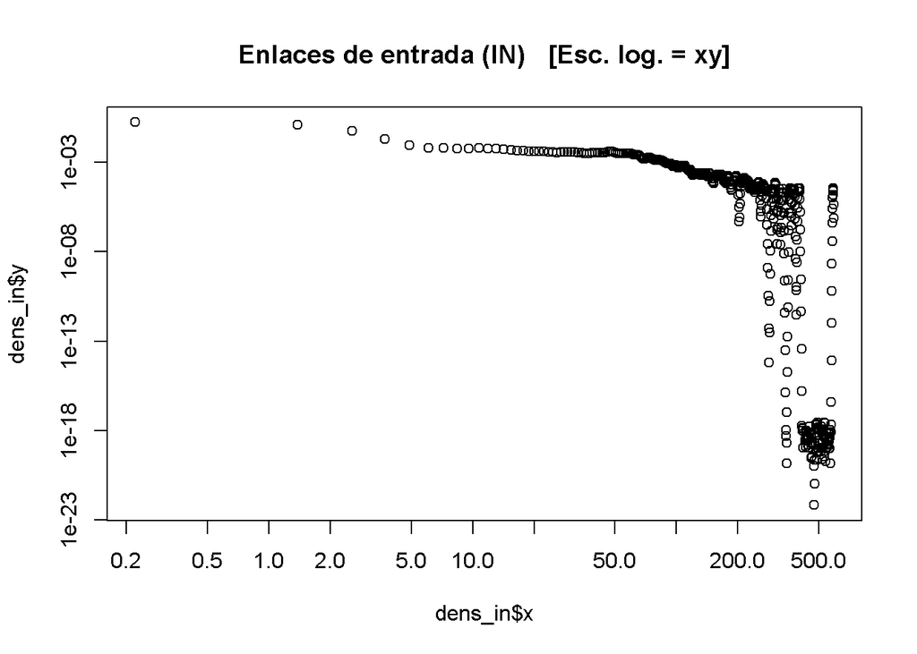

```r
#CHUNK 3: calcula los tipos de grado y pinta su distribución
# Distribución de grado:

# print("Enlaces de entrada (IN):")
dens_in<-density(degree(grf, mode = "in"))
# plot(dens_in$x, dens_in$y, main = "Enlaces de entrada (IN)")
plot(dens_in$x, dens_in$y, log="xy", main = "Enlaces de entrada (IN)   [Esc. log. = xy]")
```

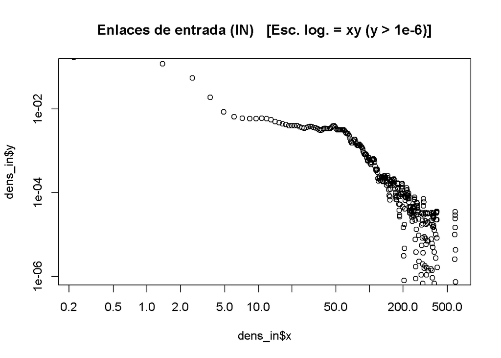

```r
plot(dens_in$x, dens_in$y, log="xy", ylim=c(1e-6,1e-1), main = "Enlaces de entrada (IN)   [Esc. log. = xy (y > 1e-6)]") # escala logarítmica (y > 1e-6)
```

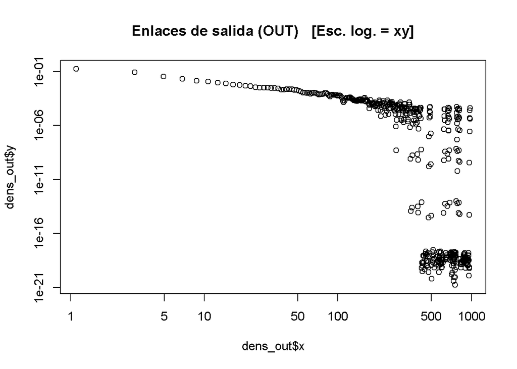

```r
# print("Enlaces de salida (OUT):")
dens_out<-density(degree(grf, mode = "out"))
# plot(dens_out$x, dens_out$y, main = "Enlaces de salida (OUT)")
plot(dens_out$x, dens_out$y, log="xy", main = "Enlaces de salida (OUT)   [Esc. log. = xy]")
```

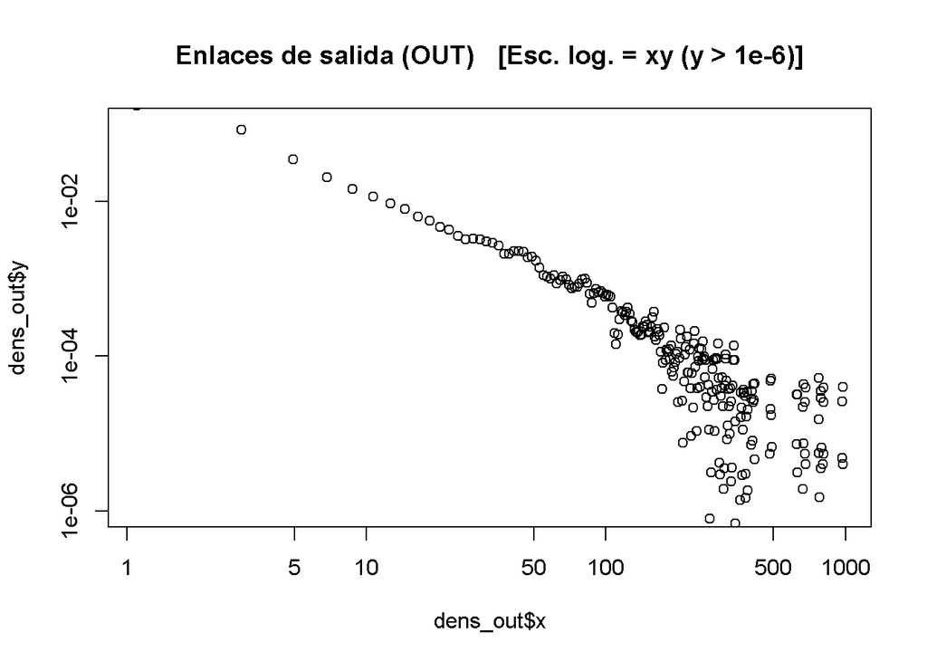

```r
plot(dens_out$x, dens_out$y, log="xy", ylim=c(1e-6,1e-1), main = "Enlaces de salida (OUT)   [Esc. log. = xy (y > 1e-6)]") # escala logarítmica (y > 1e-6)
```

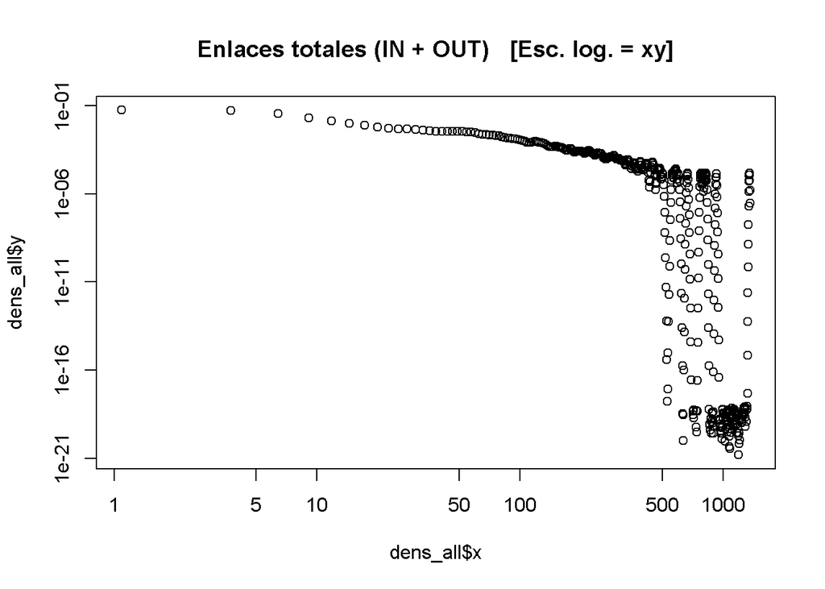

```r
# print("Enlaces totales (IN + OUT):")
dens_all<-density(degree(grf, mode = "all"))
# plot(dens_all$x, dens_all$y, main = "Enlaces totales (IN + OUT)")
plot(dens_all$x, dens_all$y, log="xy", main = "Enlaces totales (IN + OUT)   [Esc. log. = xy]")
```

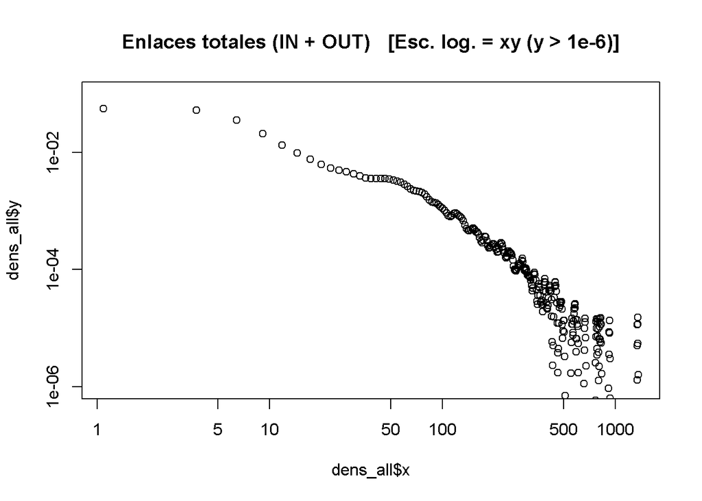

```r
plot(dens_all$x, dens_all$y, log="xy", ylim=c(1e-6,1e-1), main = "Enlaces totales (IN + OUT)   [Esc. log. = xy (y > 1e-6)]") # escala logarítmica (y > 1e-6)
```

Una vez pintados los resultados, ¿crees que es una red libre de escala? Considera usar la función power.law.fit para justificar tu respuesta.

```r
#CHUNK 4: muestra estadísticamente si la distribución de grados sigue una ley de escala
power.law.fit(degree(grf, mode = "in"))$KS.p
```

```
## [1] 0.9593985
```

```r
power.law.fit(degree(grf, mode = "out"))$KS.p
```

```
## [1] 0.9954181
```

```r
power.law.fit(degree(grf, mode = "all"))$KS.p
```

```
## [1] 0.9850113
```

Es una red libre de escala ya que la distribución de grados sigue una distribución exponencial negativa. Usamos la función power.law.fit() para contrastarlo y como devuelve un valor KS.p (p-valor del test de Kolmogorov-Smirnov) muy grande, no hay evidencia para rechazar la hipótesis (que afirma que la distribución proviene de una distribución exponencial negativa).  
Realizamos el test con la distribución de grados de entrada, de salida y con la suma de ambas y, como se veía en los gráficos, al ser muy parecidas, se puede afirmar que es una red libre de escala con cualquiera de los 3 tipos de grado, a pesar de incluir un grupo de nodos con muchos enlaces cuya distribución es menos obvia.

### Reciprocidad

¿Cuál es la reciprocidad global de esta red? ¿Cuántos enlaces recíprocos tiene?

¿Crees que la reciprocidad es una buena medida para esta red?¿Por qué?

```r
#CHUNK 5: calcula la reciprocidad
# Probabilidad de que el enlace recíproco (en dirección contraria) a un enlace también esté en el grafo:
numCandidatos <- length(unique(dat$candidate))
numVotantes <- length(unique(dat$voter))
print(paste('Hay', numCandidatos, 'candidatos (distintos).'))
```

```
## [1] "Hay 2381 candidatos (distintos)."
```

```r
print(paste('Hay', numVotantes, 'votantes (distintos).'))
```

```
## [1] "Hay 6110 votantes (distintos)."
```

```r
print(paste('Hay', numCandidatos + numVotantes - vcount(grf), 'candidatos votantes (distintos).'))
```

```
## [1] "Hay 1376 candidatos votantes (distintos)."
```

```r
print(paste('Reciprocidad =', reciprocity(grf)))
```

```
## [1] "Reciprocidad = 0.0549937379666149"
```

```r
# La cantidad de enlaces dirigidos multiplicada por la probabilidad de ser recíproco es la cantidad de enlaces recíprocos:
print(paste('Enlaces recíprocos =', reciprocity(grf) * ecount(grf) / 2))
```

```
## [1] "Enlaces recíprocos = 2942"
```

```r
# NOTA: Esto también se puede calcular con: dyad.census(grf)$mut

# Probabilidad de que haya enlaces recíprocos entre cada par de nodos conectados (incluyendo los pares de nodos no conectados entre sí):
reciprocity(grf, mode="ratio")
```

```
## [1] 0.02827432
```

La reciprocidad en este caso es obviamente baja (5,5%) ya que las votaciones se realizan solamente a los que se presentan como candidatos y, al ser éstos muchos menos (2.381) que los votantes (6.110), habrá forzosamente más enlaces hacia candidatos que en dirección contraria (de hecho, solamente 1.376 votantes son también candidatos).  
No es una buena medida para esta red, ya que hay una dirección clara en los enlaces (votantes frente a candidatos) y una clara distinción entre los grupos de candidatos y votantes (aún teniendo algunos elementos en ambos grupos). De hecho, la segunda medida de reciprocidad, inferior al 3%, indica mejor lo poco recíproca que es la relación de este grafo, ya que tiene en cuenta también los enlaces no existentes entre cada par de nodos (pares desconectados).

### Componentes conexas

En esta sección vamos a calcular las componentes conexas del grafo. Analiza qué ocurre cuando se consideran las direcciones de los enlaces y cuando no y explica por qué. Considera utilizar la función clusters de igraph para este ejercicio.

```r
#CHUNK 6: analiza cómo son las componentes conexas de este grafo
clus_F <- clusters(grf, mode = "strong")
print(paste(clus_F$no, 'componentes fuertemente conexas (grafo dirigido). Distribución del tamaño de las componentes:'))
```

```
## [1] "5816 componentes fuertemente conexas (grafo dirigido). Distribución del tamaño de las componentes:"
```

```r
table(nodos = clus_F$csize)
```

```
## nodos
##    1 1300
## 5815    1
```

Hay una única componente fuertemente conexa (con 1.300 nodos).

```r
clus_D <- clusters(grf, mode = "weak")
print(paste(clus_D$no, 'componentes débilmente conexas (grafo dirigido). Distribución del tamaño de las componentes:'))
```

```
## [1] "24 componentes débilmente conexas (grafo dirigido). Distribución del tamaño de las componentes:"
```

```r
table(nodos = clus_D$csize)
```

```
## nodos
##    2    3 7066
##   20    3    1
```

También hay 24 componentes débilmente conexas: una con 7.066 nodos, tres con 3 nodos cada una y 20 con dos nodos conectados (débilmente)…  
Si los enlaces no fuesen dirigidos, las componentes conexas serían las 24 débilmente conexas de este último caso. Si no hay dirección en el grafo, no hay conexiones débiles o fuertes, sólo hay conexiones.

Quédate con el subgrafo que involucra a los nodos contenidos en la componente conexa más grande.

```r
#CHUNK 7: crea un subgrafo llamado g2 que esté compuesto solamente por los nodos y enlaces de la componente conexa principal
cluster_principal_id <- which.max(clus_F$csize)
g2.F <- induced_subgraph(grf, which(clus_F$membership == cluster_principal_id))
g2.F$name <- paste(g2.F$name,'(Componente fuertemente conexa)')
summary(g2.F)
```

```
## IGRAPH DN-- 1300 40966 -- Wiki-elecciones (Componente fuertemente conexa)
## + attr: name (g/c), name (v/c), voto (e/n), timestamp (e/n)
```

```r
cluster_principal_id <- which.max(clus_D$csize)
g2.D <- induced_subgraph(grf, which(clus_D$membership == cluster_principal_id))
g2.D$name <- paste(g2.D$name,'(Componente débilmente conexa)')
summary(g2.D)
```

```
## IGRAPH DN-- 7066 106968 -- Wiki-elecciones (Componente débilmente conexa)
## + attr: name (g/c), name (v/c), voto (e/n), timestamp (e/n)
```

```r
# Nos quedamos con la componente débilmente conexa principal, ya que es obviamente la más grande:
g2 <- g2.D
```

### Caminos mínimos

Calcula el diámetro y el camino medio en el grafo original y en el subgrafo generado en el paso anterior. ¿Puedes explicar las diferencias y similaridades? ¿Dirías que es una red de mundo pequeño?

Primero comprobamos la red inicial completa (grf):

```r
#CHUNK 8: calcula el camino medio y el diámetro para explicar si es una red de mundo pequeño o no
diam_grf <- diameter(graph = grf, directed = TRUE, unconnected = TRUE, weights = NULL)
print(paste('Diámetro de grf =', diam_grf))
```

```
## [1] "Diámetro de grf = 10"
```

```r
dist_media_grf <- mean_distance(graph = grf, directed = TRUE, unconnected = TRUE) # == L
print(paste('Camino medio (L) de grf =', dist_media_grf))
```

```
## [1] "Camino medio (L) de grf = 3.3410114088328"
```

```r
clust_coef_grf <- transitivity(grf) # == C
print(paste('Transitividad (C) de grf =', clust_coef_grf))
```

```
## [1] "Transitividad (C) de grf = 0.12547914899234"
```

```r
# Es libre de escala, así que esta diferencia no debería ser muy grande:
print(paste('L ~ log(log(N)):', dist_media_grf, '~', log(log(vcount(grf)))))
```

```
## [1] "L ~ log(log(N)): 3.3410114088328 ~ 2.18267034428497"
```

```r
# Generamos un grafo aleatorio con mismo número de nodos y de enlaces (7.115 nodos y 106.994 enlaces):
mi_tiempo <- system.time({
  grf_rand <<- random.graph.game(n = vcount(grf), p.or.m = ecount(grf),
                                 type = "gnm", loops = FALSE, directed = TRUE)
  dist_media_grf_rand <<- mean_distance(graph = grf_rand, directed = TRUE
                                       , unconnected = !is.connected(grf_rand, "strong")) # == L_Rand
})
print(paste0("Tiempo grf_rand: ", round(mi_tiempo[3],1), " segundos."))
```

```
## [1] "Tiempo grf_rand: 3.2 segundos."
```

```r
print(paste('Camino medio de grf_rand =', dist_media_grf_rand))
```

```
## [1] "Camino medio de grf_rand = 3.57844676329335"
```

```r
clust_coef_grf_rand <- transitivity(grf_rand) # == C_Rand
print(paste('Transitividad (C_Rand) de grf_rand =', clust_coef_grf_rand))
```

```
## [1] "Transitividad (C_Rand) de grf_rand = 0.00426127735526687"
```

```r
coef_mundo_peq_grf <- (clust_coef_grf / clust_coef_grf_rand) / (dist_media_grf / dist_media_grf_rand)
print(paste('Coeficiente de mundo pequeño de grf =', coef_mundo_peq_grf))
```

```
## [1] "Coeficiente de mundo pequeño de grf = 31.5390323315599"
```

Ahora vamos con la componente (débilmente) conexa g2:

```r
diam_g2 <- diameter(graph = g2, directed = TRUE, unconnected = TRUE, weights = NULL)
print(paste('Diámetro de g2 =', diam_g2))
```

```
## [1] "Diámetro de g2 = 10"
```

```r
dist_media_g2 <- mean_distance(graph = g2, directed = TRUE, unconnected = TRUE) # == L
print(paste('Camino medio (L) de g2 =', dist_media_g2))
```

```
## [1] "Camino medio (L) de g2 = 3.34101650403497"
```

```r
clust_coef_g2 <- transitivity(g2) # == C
print(paste('Transitividad (C) de g2 =', clust_coef_g2))
```

```
## [1] "Transitividad (C) de g2 = 0.125479174872197"
```

```r
# Es libre de escala, así que esta diferencia no debería ser muy grande:
print(paste('L ~ log(log(N)):', dist_media_g2, '~', log(log(vcount(g2)))))
```

```
## [1] "L ~ log(log(N)): 3.34101650403497 ~ 2.18189092975547"
```

```r
# Generamos un grafo aleatorio con mismo número de nodos y de enlaces (7.066 nodos y 106.968 enlaces):
mi_tiempo <- system.time({
  g2_rand <<- random.graph.game(n = vcount(g2), p.or.m = ecount(g2),
                                type = "gnm", loops = FALSE, directed = TRUE)
  dist_media_g2_rand <<- mean_distance(graph = g2_rand, directed = TRUE
                                       , unconnected = !is.connected(g2_rand, "weak")) # == L_Rand
})
print(paste0("Tiempo g2_rand: ", round(mi_tiempo[3],1), " segundos."))
```

```
## [1] "Tiempo g2_rand: 2.9 segundos."
```

```r
print(paste('Camino medio de g2_rand =', dist_media_g2_rand))
```

```
## [1] "Camino medio de g2_rand = 3.57047029433735"
```

```r
clust_coef_g2_rand <- transitivity(g2_rand) # == C_Rand
print(paste('Transitividad (C_Rand) de g2_rand =', clust_coef_g2_rand))
```

```
## [1] "Transitividad (C_Rand) de g2_rand = 0.00432258330055601"
```

```r
coef_mundo_peq_g2 <- (clust_coef_g2 / clust_coef_g2_rand) / (dist_media_g2 / dist_media_g2_rand)
print(paste('Coeficiente de mundo pequeño de g2 =', coef_mundo_peq_g2))
```

```
## [1] "Coeficiente de mundo pequeño de g2 = 31.0223780539542"
```